# FDA-Project

Bitcoin Prediction

10/11/22

```r
#installing datarium
rm(list=ls())
#install.packages("datarium")
library(datarium)
```

```r
#reading data set of our project
data = read.csv(file.choose())
```

```r
head(data)
```

|  | Date | High | Low | Open | Close | Volume | Marketcap |
| --- | --- | --- | --- | --- | --- | --- | --- |
| 1 | 4/29/2013 23:59 | 147.488 | 134.0000 | 134.444 | 144.54 | 0 | 1603768865 |
| 2 | 4/30/2013 23:59 | 146.930 | 134.0500 | 144.000 | 139.00 | 0 | 1542813125 |
| 3 | 5/1/2013 23:59 | 139.890 | 107.7200 | 139.000 | 116.99 | 0 | 1298954594 |
| 4 | 5/2/2013 23:59 | 125.600 | 92.2819 | 116.380 | 105.21 | 0 | 1168517495 |
| 5 | 5/3/2013 23:59 | 108.128 | 79.1000 | 106.250 | 97.75 | 0 | 1085995169 |
| 6 | 5/4/2013 23:59 | 115.000 | 92.5000 | 98.100 | 112.50 | 0 | 1250316563 |

|  | Date <chr> | High <dbl> | Low <dbl> | Open <dbl> | Close <dbl> | Volume <dbl> | Marketcap <dbl> |
| --- | --- | --- | --- | --- | --- | --- | --- |
| 1 | 4/29/2013 23:59 | 147.488 | 134.0000 | 134.444 | 144.54 | 0 | 1603768865 |
| 2 | 4/30/2013 23:59 | 146.930 | 134.0500 | 144.000 | 139.00 | 0 | 1542813125 |
| 3 | 5/1/2013 23:59 | 139.890 | 107.7200 | 139.000 | 116.99 | 0 | 1298954594 |
| 4 | 5/2/2013 23:59 | 125.600 | 92.2819 | 116.380 | 105.21 | 0 | 1168517495 |
| 5 | 5/3/2013 23:59 | 108.128 | 79.1000 | 106.250 | 97.75 | 0 | 1085995169 |
| 6 | 5/4/2013 23:59 | 115.000 | 92.5000 | 98.100 | 112.50 | 0 | 1250316563 |

6 rows

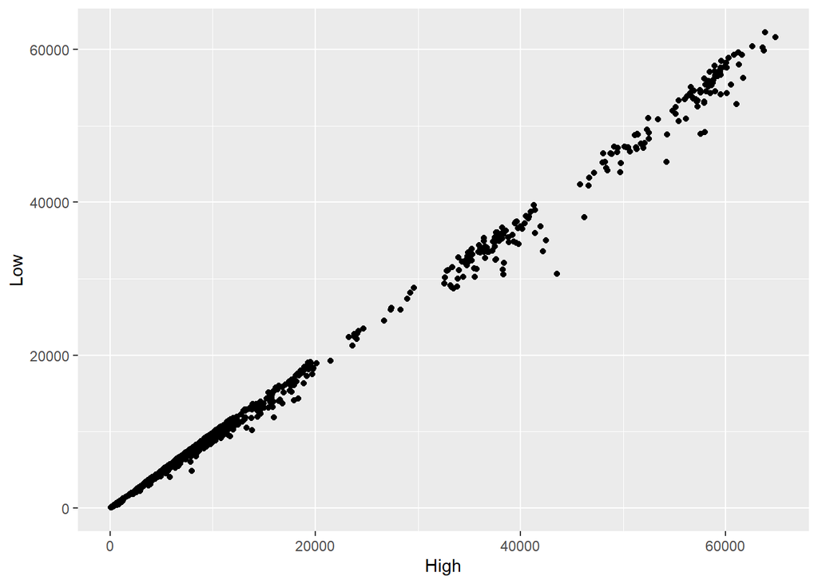

```r
#visualization for high and low
library(ggplot2)
par(mar = c(2,2,2,2))
ggplot(data,aes(x=High,y=Low))+geom_point()
```

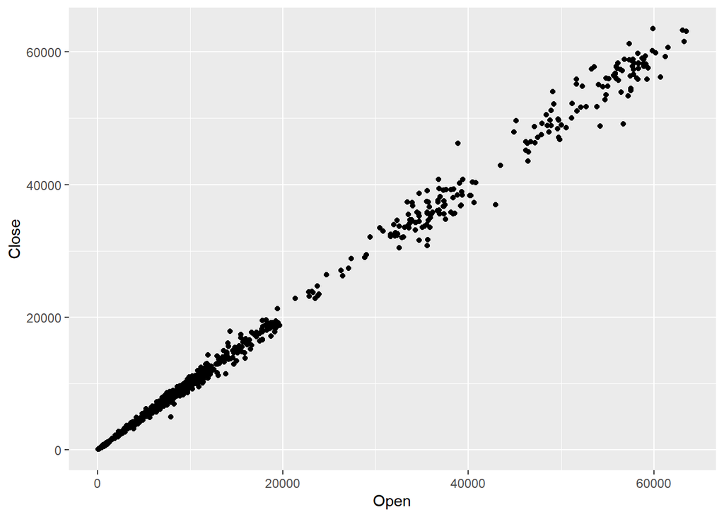

```r
#visualization for open and close
library(ggplot2)
par(mar = c(2,2,2,2))
ggplot(data,aes(x=Open,y=Close))+geom_point()
```

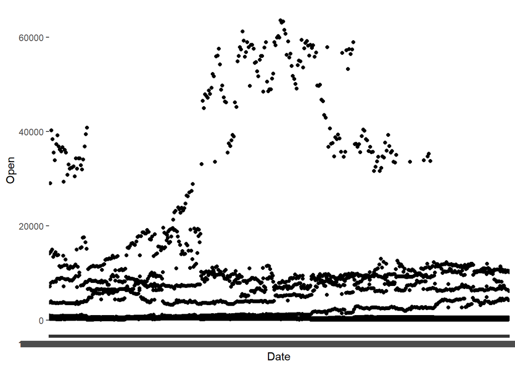

```r
#visualization for date and open
library(ggplot2)
par(mar = c(2,2,2,2))
ggplot(data,aes(x=Date,y=Open))+geom_point()
```

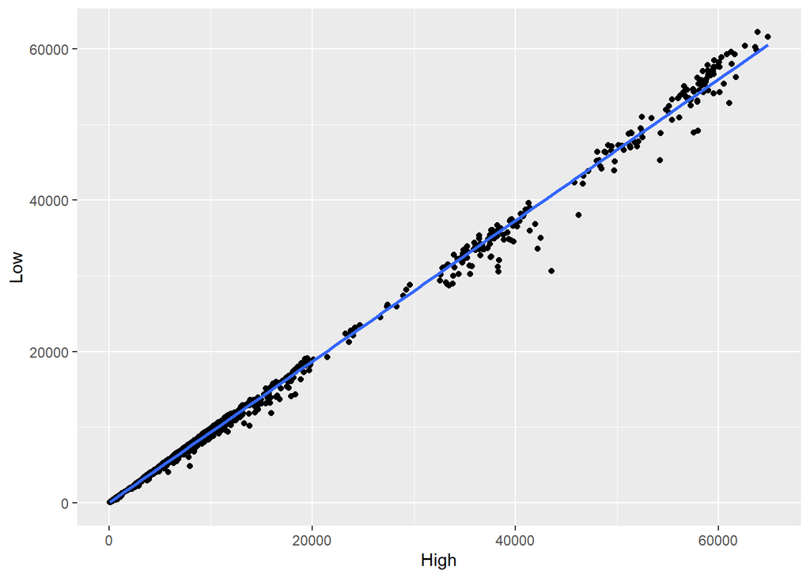

```r
#geom smooth method for high and low
ggplot(data,aes(x=High,y=Low))+geom_point()+geom_smooth(method = 'lm',se=FALSE)
```

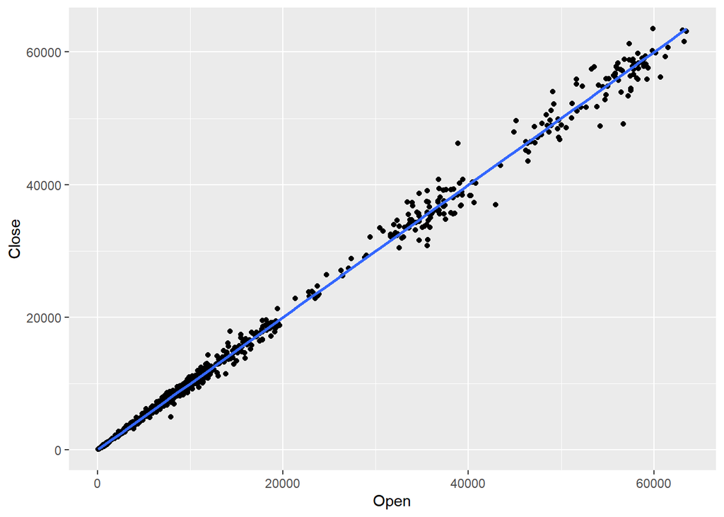

```r
#geom smooth method for close and open
ggplot(data,aes(x=Open,y=Close))+geom_point()+geom_smooth(method = 'lm',se=FALSE)
```

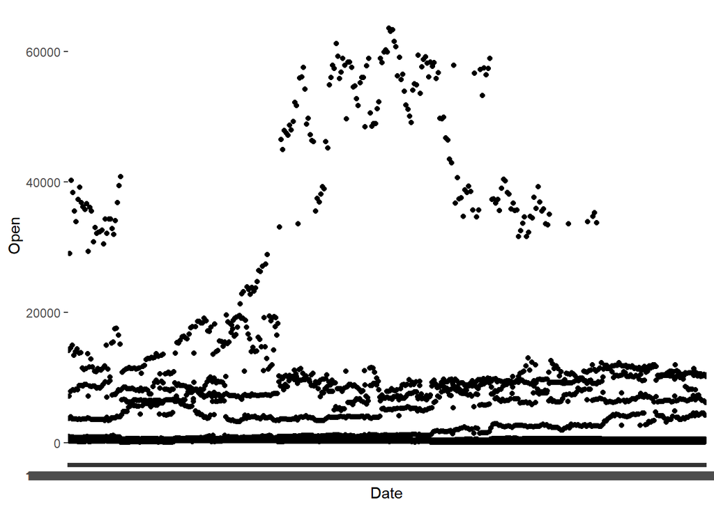

```r
#geom smooth method for date and open
ggplot(data,aes(x=Date,y=Open))+geom_point()+geom_smooth(method = 'lm',se=FALSE)
```

#correlation for models we choosen:####

```r
#correlation between high and low
cor(data$High,data$Low)
```

```
## [1] 0.9988414
```

```r
#correlation between open and close
cor(data$Open,data$Close)
```

```
## [1] 0.9986457
```

#assinging the models :### ##model 1 for high and low #model 2 for open and close #model 3 for marketcap and open

```r
#assigning model1 for low and high
model1 = lm(High~Low,data)
model1
```

```
##
## Call:
## lm(formula = High ~ Low, data = data)
##
## Coefficients:
## (Intercept)          Low
##      -46.39         1.07
```

```r
#assigning model2 for open and close
model2 = lm(Open~Close,data)
model2
```

```
##
## Call:
## lm(formula = Open ~ Close, data = data)
##
## Coefficients:
## (Intercept)        Close
##      3.9350       0.9978
```

```r
#assigning model3 for date and open
model3 = lm(Marketcap~Open,data)
model3
```

```
##
## Call:
## lm(formula = Marketcap ~ Open, data = data)
##
## Coefficients:
## (Intercept)         Open
##  -4.124e+09    1.865e+07
```

#summary for models taken###

```r
#summary for model1
summary(model1)
```

```
##
## Call:
## lm(formula = High ~ Low, data = data)
##
## Residuals:
##     Min      1Q  Median      3Q     Max
## -2965.4  -158.7    21.5    43.5 10764.8
##
## Coefficients:
##               Estimate Std. Error  t value Pr(>|t|)
## (Intercept) -4.639e+01  1.193e+01   -3.888 0.000103 ***
## Low          1.070e+00  9.429e-04 1134.774  < 2e-16 ***
## ---
## Signif. codes:  0 '***' 0.001 '**' 0.01 '*' 0.05 '.' 0.1 ' ' 1
##
## Residual standard error: 560.4 on 2989 degrees of freedom
## Multiple R-squared:  0.9977, Adjusted R-squared:  0.9977
## F-statistic: 1.288e+06 on 1 and 2989 DF,  p-value: < 2.2e-16
```

```r
#summary for model2
summary(model2)
```

```
##
## Call:
## lm(formula = Open ~ Close, data = data)
##
## Residuals:
##     Min      1Q  Median      3Q     Max
## -7209.8   -29.4    -3.6    19.8  7670.5
##
## Coefficients:
##              Estimate Std. Error  t value Pr(>|t|)
## (Intercept) 3.935e+00  1.249e+01    0.315    0.753
## Close       9.978e-01  9.508e-04 1049.433   <2e-16 ***
## ---
## Signif. codes:  0 '***' 0.001 '**' 0.01 '*' 0.05 '.' 0.1 ' ' 1
##
## Residual standard error: 587.4 on 2989 degrees of freedom
## Multiple R-squared:  0.9973, Adjusted R-squared:  0.9973
## F-statistic: 1.101e+06 on 1 and 2989 DF,  p-value: < 2.2e-16
```

```r
#summary for model3
summary(model3)
```

```
##
## Call:
## lm(formula = Marketcap ~ Open, data = data)
##
## Residuals:
##        Min         1Q     Median         3Q        Max
## -1.339e+11 -1.958e+09  1.614e+09  2.933e+09  1.387e+11
##
## Coefficients:
##               Estimate Std. Error t value Pr(>|t|)
## (Intercept) -4.124e+09  2.549e+08  -16.18   <2e-16 ***
## Open         1.865e+07  1.942e+04  960.52   <2e-16 ***
## ---
## Signif. codes:  0 '***' 0.001 '**' 0.01 '*' 0.05 '.' 0.1 ' ' 1
##
## Residual standard error: 1.199e+10 on 2989 degrees of freedom
## Multiple R-squared:  0.9968, Adjusted R-squared:  0.9968
## F-statistic: 9.226e+05 on 1 and 2989 DF,  p-value: < 2.2e-16
```

#data

```r
head(data)
```

|  | Date | High | Low | Open | Close | Volume | Marketcap |
| --- | --- | --- | --- | --- | --- | --- | --- |
| 1 | 4/29/2013 23:59 | 147.488 | 134.0000 | 134.444 | 144.54 | 0 | 1603768865 |
| 2 | 4/30/2013 23:59 | 146.930 | 134.0500 | 144.000 | 139.00 | 0 | 1542813125 |
| 3 | 5/1/2013 23:59 | 139.890 | 107.7200 | 139.000 | 116.99 | 0 | 1298954594 |
| 4 | 5/2/2013 23:59 | 125.600 | 92.2819 | 116.380 | 105.21 | 0 | 1168517495 |
| 5 | 5/3/2013 23:59 | 108.128 | 79.1000 | 106.250 | 97.75 | 0 | 1085995169 |
| 6 | 5/4/2013 23:59 | 115.000 | 92.5000 | 98.100 | 112.50 | 0 | 1250316563 |

|  | Date <chr> | High <dbl> | Low <dbl> | Open <dbl> | Close <dbl> | Volume <dbl> | Marketcap <dbl> |
| --- | --- | --- | --- | --- | --- | --- | --- |
| 1 | 4/29/2013 23:59 | 147.488 | 134.0000 | 134.444 | 144.54 | 0 | 1603768865 |
| 2 | 4/30/2013 23:59 | 146.930 | 134.0500 | 144.000 | 139.00 | 0 | 1542813125 |
| 3 | 5/1/2013 23:59 | 139.890 | 107.7200 | 139.000 | 116.99 | 0 | 1298954594 |
| 4 | 5/2/2013 23:59 | 125.600 | 92.2819 | 116.380 | 105.21 | 0 | 1168517495 |
| 5 | 5/3/2013 23:59 | 108.128 | 79.1000 | 106.250 | 97.75 | 0 | 1085995169 |
| 6 | 5/4/2013 23:59 | 115.000 | 92.5000 | 98.100 | 112.50 | 0 | 1250316563 |

6 rows

#evaluating the linearity assumption for every model taken####

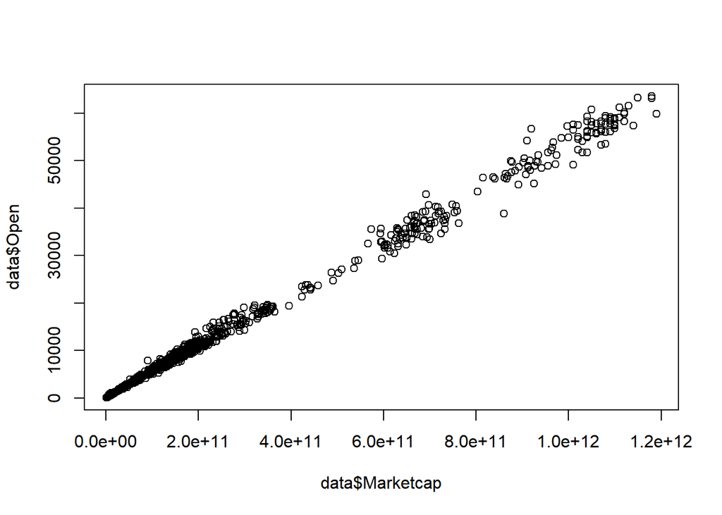

```r
#evaluating the linearity assumption among Marketcap and Open
plot(data$Marketcap,data$Open)
```

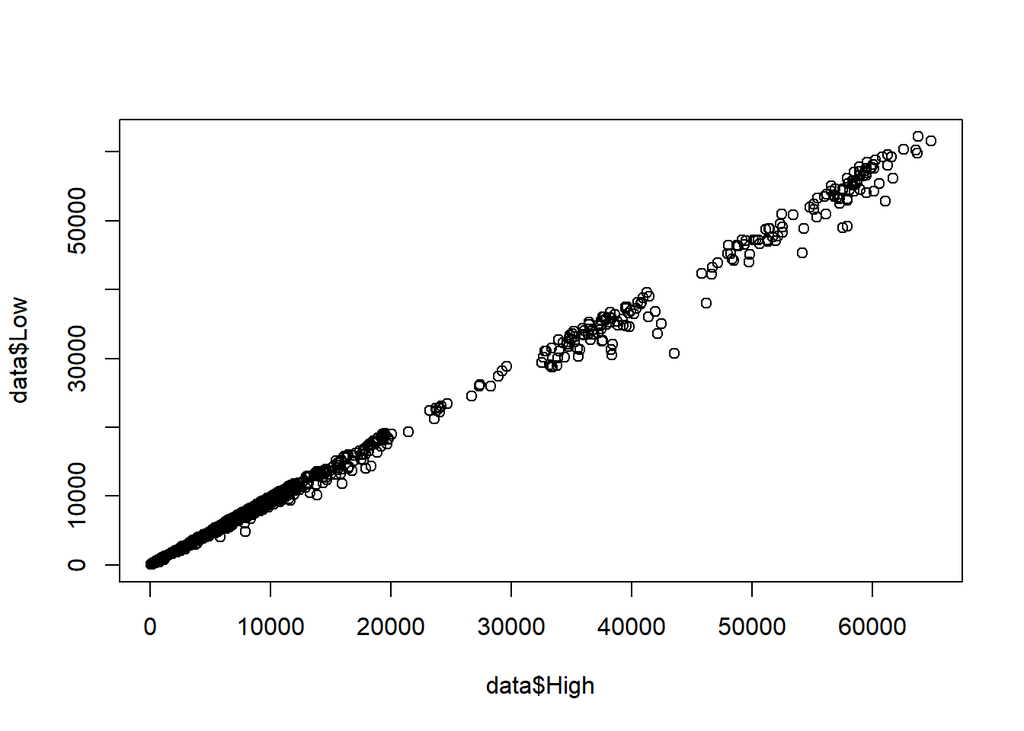

```r
#evaluating the linearity assumption among Low and High
plot(data$High,data$Low)
```

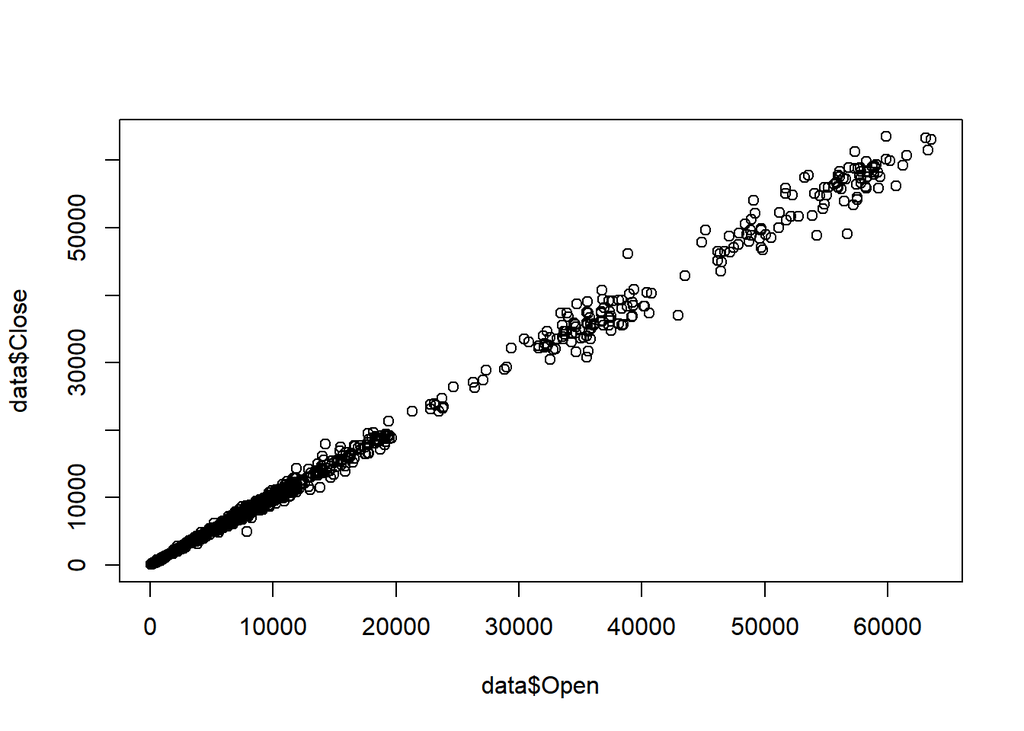

```r
#evaluating the linearity assumption among open and Close
plot(data$Open,data$Close)
```

#plotting models####

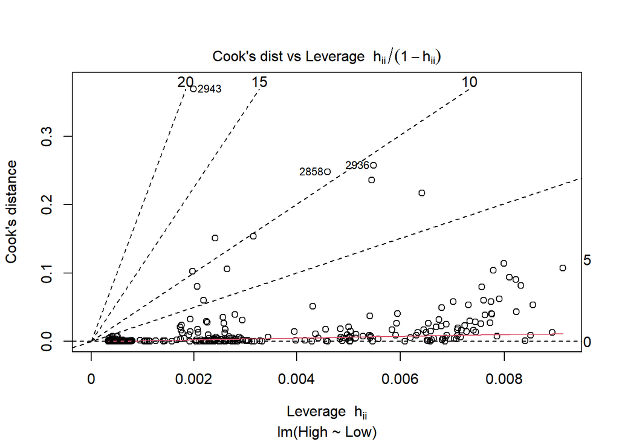

```r
#plotting model1
plot(model1,6)
```

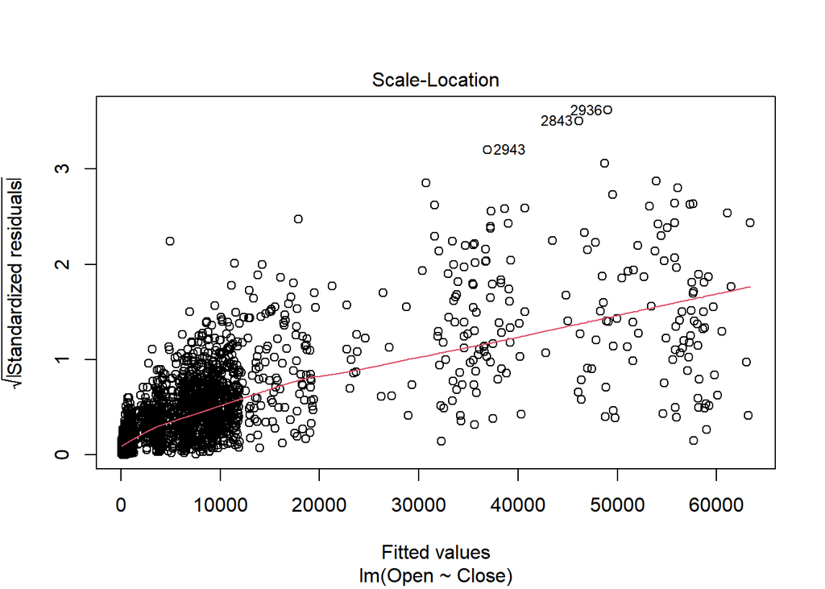

```r
#plotting model2
plot(model2,3)
```

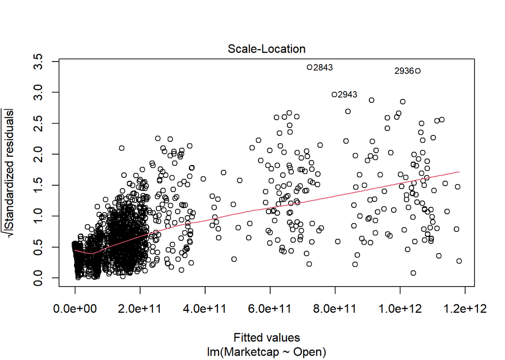

```r
#plotting model3
plot(model3,3)
```

#histogram for all the 3 models taken :#

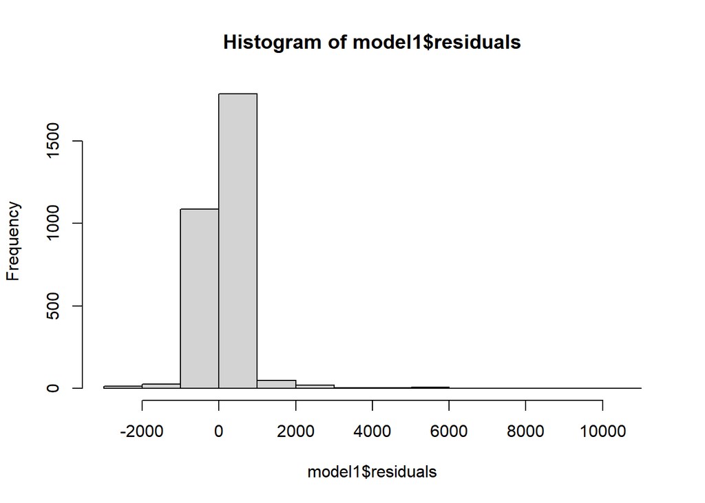

```r
hist(model1$residuals)
```

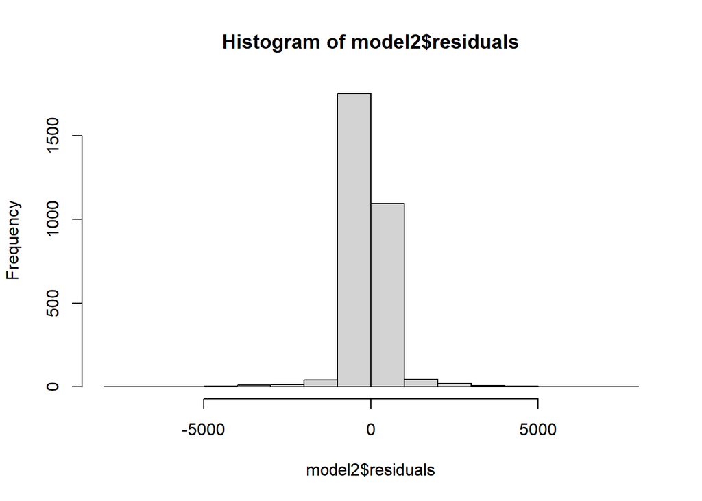

```r
hist(model2$residuals)
```

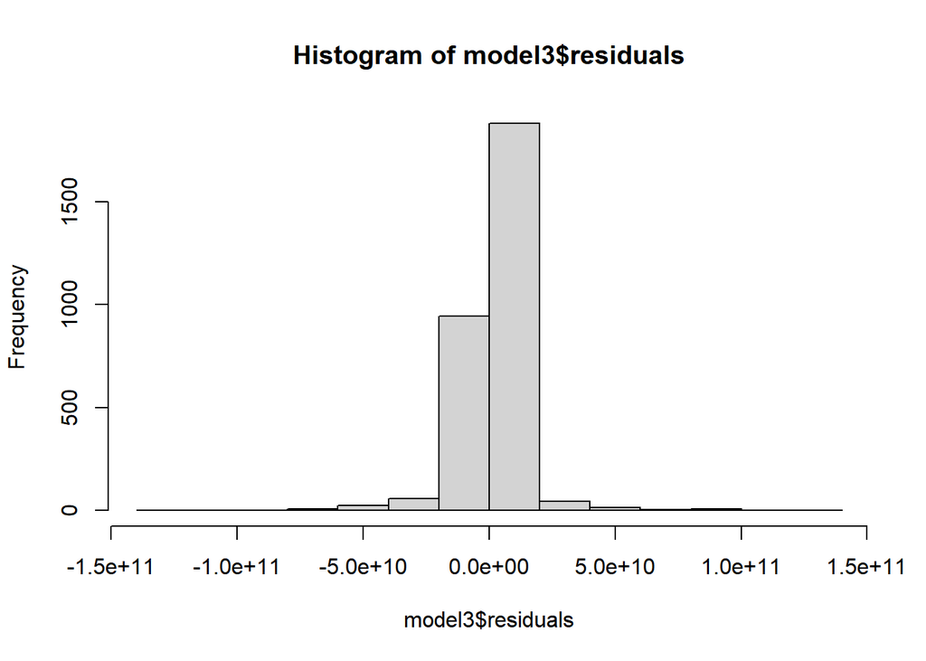

```r
hist(model3$residuals)
```

#normal QQ plots for all the 3 models :######

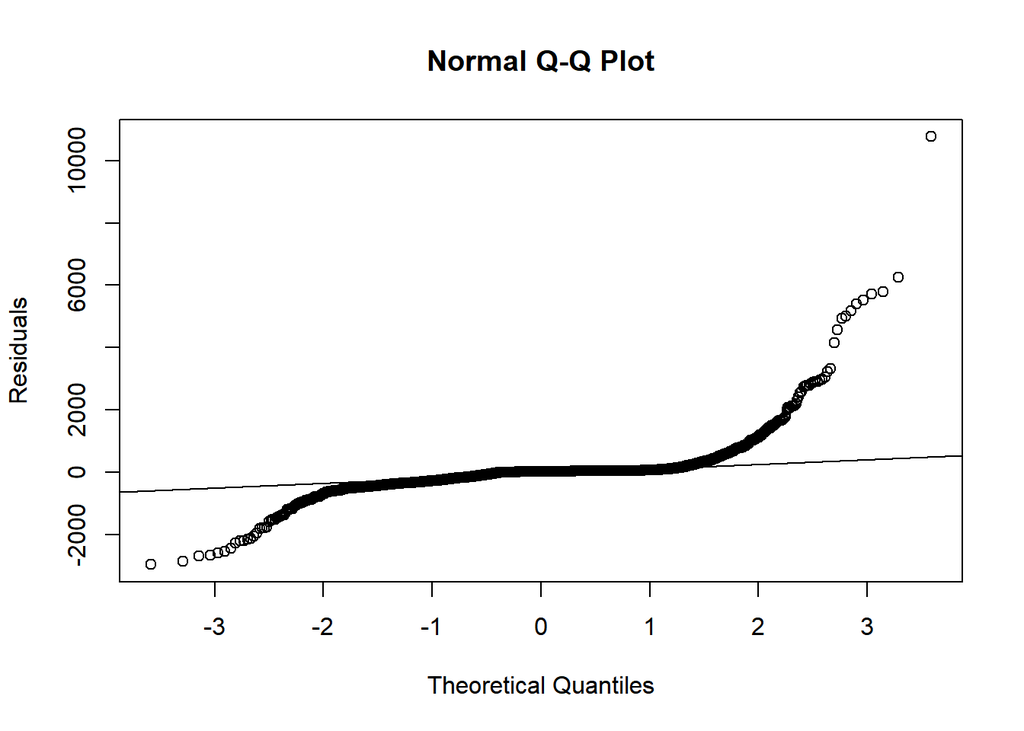

```r
qqnorm(model1$residuals,ylab = "Residuals")
qqline(model1$residuals)
```

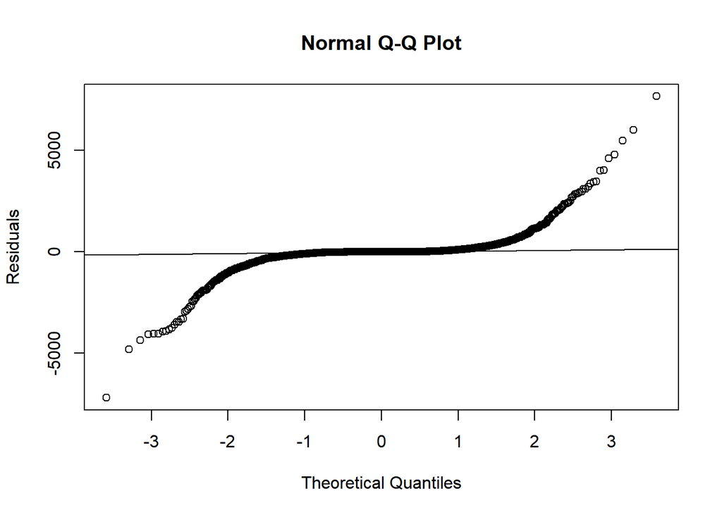

```r
qqnorm(model2$residuals,ylab = "Residuals")
qqline(model2$residuals)
```

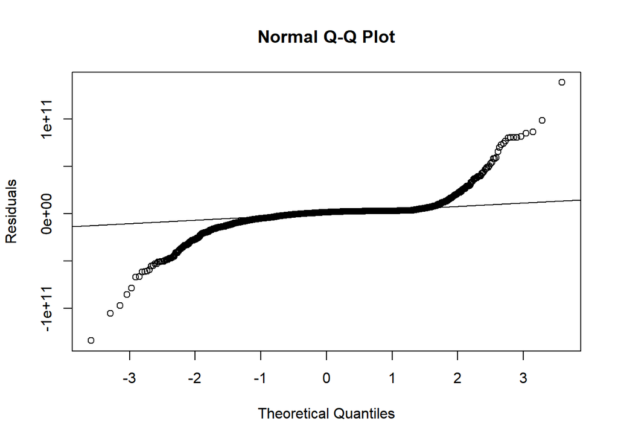

```r
qqnorm(model3$residuals,ylab = "Residuals")
qqline(model3$residuals)
```

#Barplots for different scienorios:#####

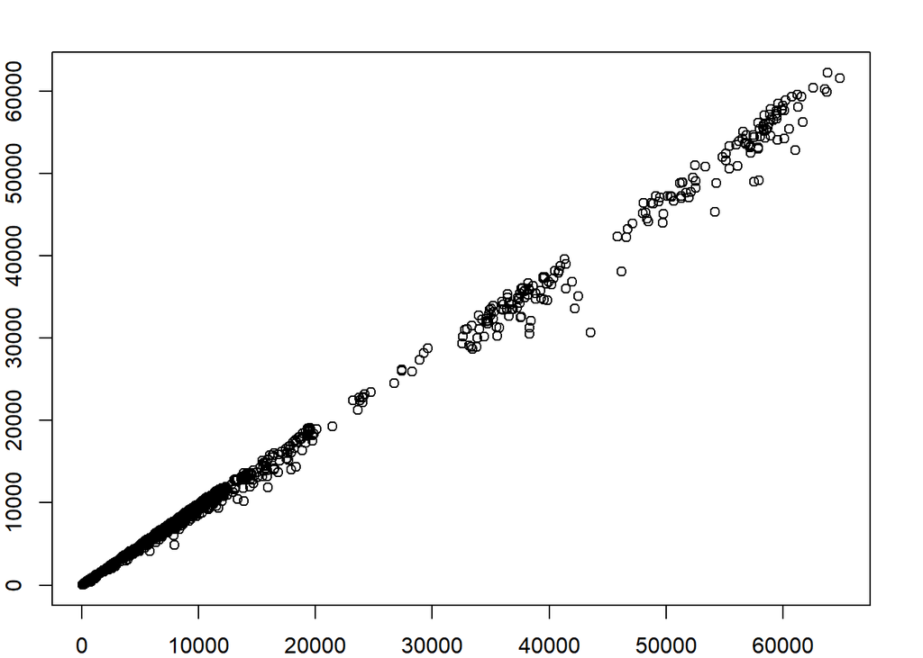

```r
library(graphics)
# data = read.table("coin_Bitcoin.csv",header=TRUE,sep = ",")
View(data)
par(mar=c(2,2,2,2))
plot(data$High,data$Low)
```

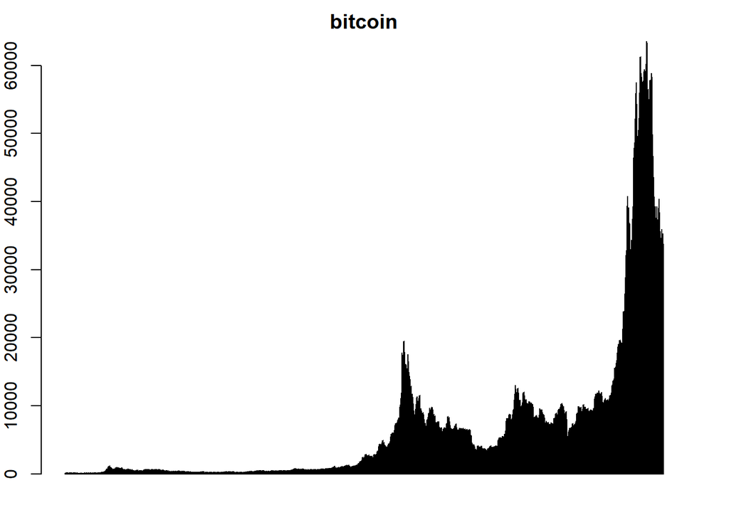

```r
barplot(data$Open,main = "bitcoin",xlab = "index",ylab = "Open values")
```

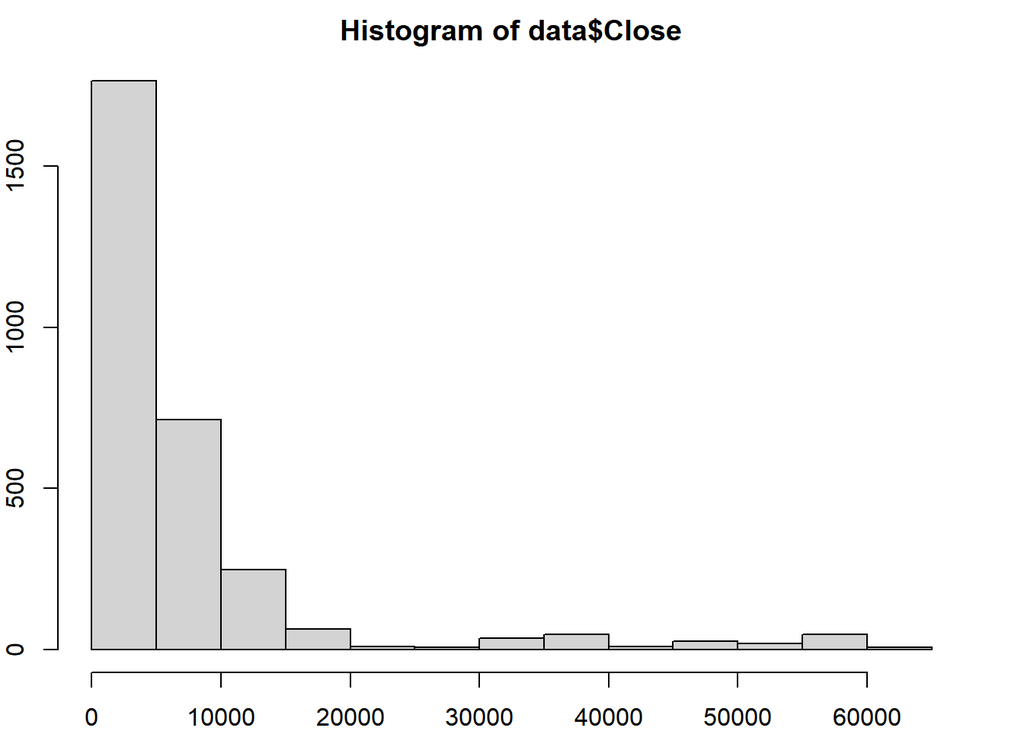

```r
hist(data$Close)
```

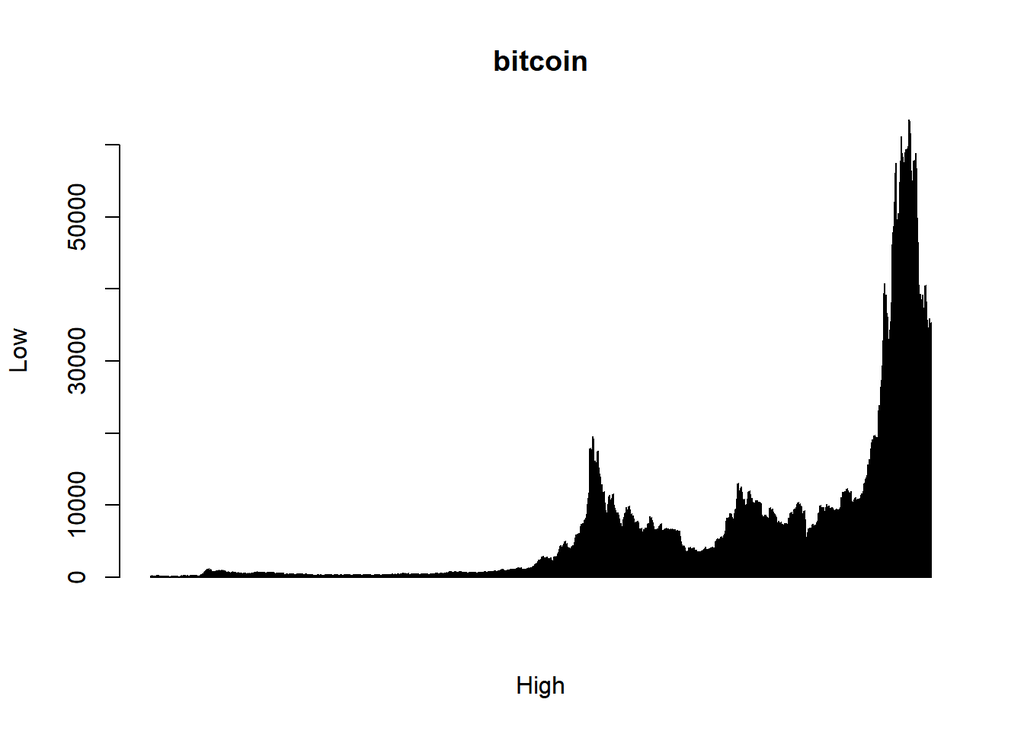

```r
barplot(data$Open,main = "bitcoin",xlab = "High",ylab = "Low")
```

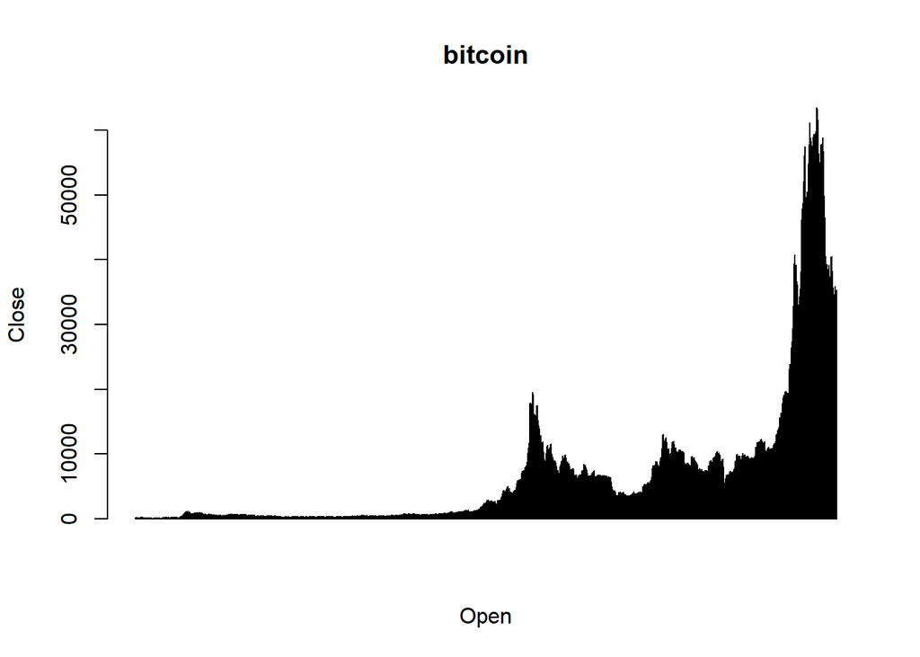

```r
barplot(data$Open,main = "bitcoin",xlab = "Open",ylab = "Close")
```

#Forecasting using Prophet in R

#Loading the Packages

```r
#install.packages('prophet')
library(prophet)
library(tidyverse)
#Loading the Dataset
bitcoin = read.csv(file.choose())
head(bitcoin)
```

|  | ds | y |
| --- | --- | --- |
| 1 | 2015-06-13 | 232.402 |
| 2 | 2015-06-14 | 233.543 |
| 3 | 2015-06-15 | 236.823 |
| 4 | 2015-06-16 | 250.895 |
| 5 | 2015-06-17 | 249.284 |
| 6 | 2015-06-18 | 249.007 |

|  | ds <chr> | y <dbl> |  |  |
| --- | --- | --- | --- | --- |
| 1 | 2015-06-13 | 232.402 |  |  |
| 2 | 2015-06-14 | 233.543 |  |  |
| 3 | 2015-06-15 | 236.823 |  |  |
| 4 | 2015-06-16 | 250.895 |  |  |
| 5 | 2015-06-17 | 249.284 |  |  |
| 6 | 2015-06-18 | 249.007 |  |  |

6 rows

```r
#Calling the Prophet Function to Fit the Model
Model1 = prophet(bitcoin)
```

```
## Disabling daily seasonality. Run prophet with daily.seasonality=TRUE to override this.
```

```r
Future1 = make_future_dataframe(Model1, periods = 365)
tail(Future1)
```

|  | ds |
| --- | --- |
| 2185 | 2021-06-05 |
| 2186 | 2021-06-06 |
| 2187 | 2021-06-07 |
| 2188 | 2021-06-08 |
| 2189 | 2021-06-09 |
| 2190 | 2021-06-10 |

|  | ds <dttm> |  |  |  |
| --- | --- | --- | --- | --- |
| 2185 | 2021-06-05 |  |  |  |
| 2186 | 2021-06-06 |  |  |  |
| 2187 | 2021-06-07 |  |  |  |
| 2188 | 2021-06-08 |  |  |  |
| 2189 | 2021-06-09 |  |  |  |
| 2190 | 2021-06-10 |  |  |  |

6 rows

```r
Forecast1 = predict(Model1, Future1)
tail(Forecast1[c('ds','yhat','yhat_lower','yhat_upper')])
```

|  | ds | yhat | yhat_lower | yhat_upper |
| --- | --- | --- | --- | --- |
| 2185 | 2021-06-05 | 8757.976 | -257.84673 | 18045.05 |
| 2186 | 2021-06-06 | 8751.903 | -392.21825 | 17974.70 |
| 2187 | 2021-06-07 | 8783.213 | -415.33333 | 18471.82 |
| 2188 | 2021-06-08 | 8792.789 | -597.93016 | 18380.14 |
| 2189 | 2021-06-09 | 8815.195 | -15.67098 | 18880.30 |
| 2190 | 2021-06-10 | 8823.990 | -548.69663 | 18230.48 |

|  | ds <dttm> | yhat <dbl> | yhat_lower <dbl> | yhat_upper <dbl> |
| --- | --- | --- | --- | --- |
| 2185 | 2021-06-05 | 8757.976 | -257.84673 | 18045.05 |
| 2186 | 2021-06-06 | 8751.903 | -392.21825 | 17974.70 |
| 2187 | 2021-06-07 | 8783.213 | -415.33333 | 18471.82 |
| 2188 | 2021-06-08 | 8792.789 | -597.93016 | 18380.14 |
| 2189 | 2021-06-09 | 8815.195 | -15.67098 | 18880.30 |
| 2190 | 2021-06-10 | 8823.990 | -548.69663 | 18230.48 |

6 rows

```r
# show mean of predicted price and actual price of bitcoin
mean(Forecast1$yhat)
```

```
## [1] 5345.211
```

```r
mean(bitcoin$y)
```

```
## [1] 4683.317
```

```r
#summary of price we predicion we did.
summary(Forecast1)
```

```
##        ds                          trend         additive_terms
##  Min.   :2015-06-13 00:00:00   Min.   : -369.6   Min.   :-1484.6614
##  1st Qu.:2016-12-11 06:00:00   1st Qu.:  927.7   1st Qu.: -332.7929
##  Median :2018-06-11 12:00:00   Median : 6325.6   Median :   95.2839
##  Mean   :2018-06-11 12:00:00   Mean   : 5345.4   Mean   :   -0.1621
##  3rd Qu.:2019-12-10 18:00:00   3rd Qu.: 8677.2   3rd Qu.:  518.8123
##  Max.   :2021-06-10 00:00:00   Max.   :12541.1   Max.   :  780.4954
##  additive_terms_lower additive_terms_upper     weekly
##  Min.   :-1484.6614   Min.   :-1484.6614   Min.   :-14.111503
##  1st Qu.: -332.7929   1st Qu.: -332.7929   1st Qu.: -6.686426
##  Median :   95.2839   Median :   95.2839   Median :  0.115430
##  Mean   :   -0.1621   Mean   :   -0.1621   Mean   : -0.000053
##  3rd Qu.:  518.8123   3rd Qu.:  518.8123   3rd Qu.:  8.430993
##  Max.   :  780.4954   Max.   :  780.4954   Max.   : 12.714781
##   weekly_lower         weekly_upper            yearly
##  Min.   :-14.111503   Min.   :-14.111503   Min.   :-1470.620
##  1st Qu.: -6.686426   1st Qu.: -6.686426   1st Qu.: -331.556
##  Median :  0.115430   Median :  0.115430   Median :   94.486
##  Mean   : -0.000053   Mean   : -0.000053   Mean   :   -0.162
##  3rd Qu.:  8.430993   3rd Qu.:  8.430993   3rd Qu.:  519.992
##  Max.   : 12.714781   Max.   : 12.714781   Max.   :  767.801
##   yearly_lower        yearly_upper       multiplicative_terms
##  Min.   :-1470.620   Min.   :-1470.620   Min.   :0
##  1st Qu.: -331.556   1st Qu.: -331.556   1st Qu.:0
##  Median :   94.486   Median :   94.486   Median :0
##  Mean   :   -0.162   Mean   :   -0.162   Mean   :0
##  3rd Qu.:  519.992   3rd Qu.:  519.992   3rd Qu.:0
##  Max.   :  767.801   Max.   :  767.801   Max.   :0
##  multiplicative_terms_lower multiplicative_terms_upper   yhat_lower
##  Min.   :0                  Min.   :0                  Min.   :-2154.8
##  1st Qu.:0                  1st Qu.:0                  1st Qu.: -275.8
##  Median :0                  Median :0                  Median : 3632.4
##  Mean   :0                  Mean   :0                  Mean   : 3604.1
##  3rd Qu.:0                  3rd Qu.:0                  3rd Qu.: 7081.1
##  Max.   :0                  Max.   :0                  Max.   :11424.7
##    yhat_upper     trend_lower       trend_upper           yhat
##  Min.   :  419   Min.   : -492.9   Min.   : -369.6   Min.   : -841.8
##  1st Qu.: 2336   1st Qu.:  731.6   1st Qu.:  927.7   1st Qu.: 1048.7
##  Median : 7900   Median : 4862.3   Median : 6325.6   Median : 6609.3
##  Mean   : 7128   Mean   : 4756.5   Mean   : 5975.7   Mean   : 5345.2
##  3rd Qu.:10526   3rd Qu.: 8677.2   3rd Qu.: 8719.2   3rd Qu.: 8651.6
##  Max.   :18880   Max.   :12541.1   Max.   :18185.3   Max.   :12724.5
```

```r
#Plotting the Model Estimates
dyplot.prophet(Model1, Forecast1)
```

[interactive chart not shown]

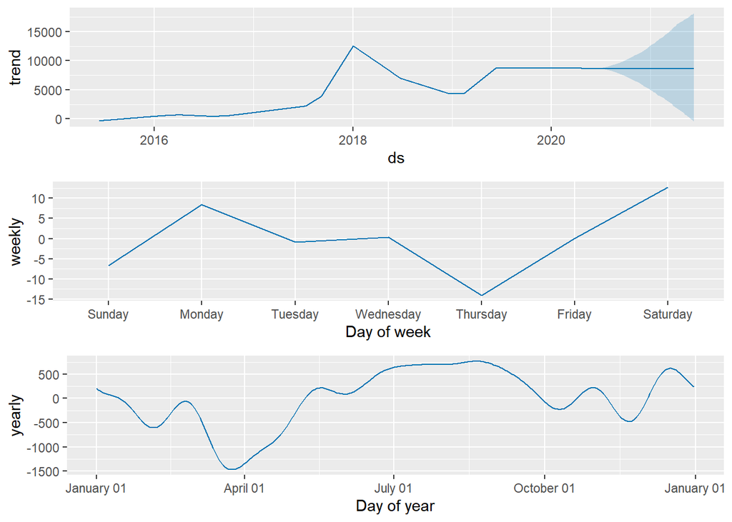

```r
prophet_plot_components(Model1, Forecast1)
```

#Forecasting using SVM in R

#Loading the Packages

```r
#install.packages('caTools')
library(caTools)
#install.packages('caret')
library(caret)
#install.packages('kernlab')
library(kernlab)
#Loading the Dataset
svm = read.csv(file.choose())
head(svm)
```

|  | ds | yL | yH | yO | yC |
| --- | --- | --- | --- | --- | --- |
| 1 | 5/27/2021 23:59 | 40379.62 | 37247.90 | 39316.89 | 38436.97 |
| 2 | 5/28/2021 23:59 | 38856.97 | 34779.04 | 38507.08 | 35697.61 |
| 3 | 5/29/2021 23:59 | 37234.50 | 33693.93 | 35684.16 | 34616.07 |
| 4 | 5/30/2021 23:59 | 36400.67 | 33520.74 | 34607.41 | 35678.13 |
| 5 | 5/31/2021 23:59 | 37468.25 | 34241.94 | 35658.59 | 37332.85 |
| 6 | 6/1/2021 23:59 | 37896.74 | 35787.09 | 37293.79 | 36684.92 |

|  | ds <chr> | yL <dbl> | yH <dbl> | yO <dbl> | yC <dbl> |
| --- | --- | --- | --- | --- | --- |
| 1 | 5/27/2021 23:59 | 40379.62 | 37247.90 | 39316.89 | 38436.97 |
| 2 | 5/28/2021 23:59 | 38856.97 | 34779.04 | 38507.08 | 35697.61 |
| 3 | 5/29/2021 23:59 | 37234.50 | 33693.93 | 35684.16 | 34616.07 |
| 4 | 5/30/2021 23:59 | 36400.67 | 33520.74 | 34607.41 | 35678.13 |
| 5 | 5/31/2021 23:59 | 37468.25 | 34241.94 | 35658.59 | 37332.85 |
| 6 | 6/1/2021 23:59 | 37896.74 | 35787.09 | 37293.79 | 36684.92 |

6 rows

```r
svm = svm[2:5]
svm
```

| yL | yH | yO | yC |
| --- | --- | --- | --- |
| 40379.62 | 37247.90 | 39316.89 | 38436.97 |
| 38856.97 | 34779.04 | 38507.08 | 35697.61 |
| 37234.50 | 33693.93 | 35684.16 | 34616.07 |
| 36400.67 | 33520.74 | 34607.41 | 35678.13 |
| 37468.25 | 34241.94 | 35658.59 | 37332.85 |
| 37896.74 | 35787.09 | 37293.79 | 36684.92 |
| 38231.34 | 35966.31 | 36699.92 | 37575.18 |
| 39478.95 | 37243.97 | 37599.41 | 39208.77 |
| 39242.49 | 35717.72 | 39242.49 | 36894.41 |
| 37917.71 | 34900.41 | 36880.16 | 35551.96 |

[output cut: 31 more lines]

| yL <dbl> | yH <dbl> | yO <dbl> | yC <dbl> |  |
| --- | --- | --- | --- | --- |
| 40379.62 | 37247.90 | 39316.89 | 38436.97 |  |
| 38856.97 | 34779.04 | 38507.08 | 35697.61 |  |
| 37234.50 | 33693.93 | 35684.16 | 34616.07 |  |
| 36400.67 | 33520.74 | 34607.41 | 35678.13 |  |
| 37468.25 | 34241.94 | 35658.59 | 37332.85 |  |
| 37896.74 | 35787.09 | 37293.79 | 36684.92 |  |
| 38231.34 | 35966.31 | 36699.92 | 37575.18 |  |
| 39478.95 | 37243.97 | 37599.41 | 39208.77 |  |
| 39242.49 | 35717.72 | 39242.49 | 36894.41 |  |
| 37917.71 | 34900.41 | 36880.16 | 35551.96 |  |

1-10 of 41 rows

```r
set.seed(3033)
intrain = createDataPartition(y = svm$yC, p=0.7, list = FALSE)
training = svm[intrain,]
testing = svm[-intrain]
dim(training);
```

```
## [1] 29  4
```

```r
dim(testing)
```

[output not shown]

```r
anyNA(svm)
```

```
## [1] FALSE
```

```r
training[["yC"]] = factor(training[["yC"]])
trctr1 = trainControl(method = "repeatedcv", number = 10, repeats = 3)
```

```r
svm_Linear = train(yC~ ., data = training, method = "svmLinear",
                   trControl=trctr1,
                   preProcess = c("center","scale"),
                   tuneLength = 10)
svm_Linear
```

```
## Support Vector Machines with Linear Kernel
##
## 29 samples
##  3 predictor
## 29 classes: '31637.78006', '32186.27767', '32505.65982', '33472.63175', '33560.70784', '33572.11765', '33723.02898', '33746.00246', '34662.43589', '34668.5484', '35040.83725', '35287.77977', '35551.95873', '35552.51715', '35615.86927', '35678.1292', '35697.60639', '35787.24478', '35867.77774', '3…
##
## Pre-processing: centered (3), scaled (3)
## Resampling: Cross-Validated (10 fold, repeated 3 times)
## Summary of sample sizes: 22, 26, 25, 24, 28, 27, ...
## Resampling results:
##
##   Accuracy   Kappa
##   0.1780612  0.07502403
##
## Tuning parameter 'C' was held constant at a value of 1
```

#Forecasting using ARIMA in R #Loading the Packages

```r
library(readr)
#install.packages('mlr')
library(mlr)
library(readxl)
#install.packages('forecast')
library(forecast)
ARIMA = read.csv(file.choose())
head(ARIMA)
```

|  | ds | yL | yH | yO | y | Volume | Marketcap |
| --- | --- | --- | --- | --- | --- | --- | --- |
| 1 | 6/13/2015 23:59 | 232.652 | 229.210 | 229.920 | 232.402 | 13305300 | 3316504361 |
| 2 | 6/14/2015 23:59 | 234.858 | 232.004 | 232.442 | 233.543 | 12165900 | 3333657006 |
| 3 | 6/15/2015 23:59 | 237.836 | 233.422 | 233.422 | 236.823 | 19912100 | 3381329191 |
| 4 | 6/16/2015 23:59 | 251.742 | 236.122 | 236.765 | 250.895 | 41612000 | 3582987588 |
| 5 | 6/17/2015 23:59 | 256.853 | 246.476 | 250.823 | 249.284 | 43858400 | 3560953387 |
| 6 | 6/18/2015 23:59 | 252.108 | 244.127 | 249.428 | 249.007 | 30980200 | 3557986321 |

|  | ds <chr> | yL <dbl> | yH <dbl> | yO <dbl> | y <dbl> | Volume <dbl> | Marketcap <dbl> |
| --- | --- | --- | --- | --- | --- | --- | --- |
| 1 | 6/13/2015 23:59 | 232.652 | 229.210 | 229.920 | 232.402 | 13305300 | 3316504361 |
| 2 | 6/14/2015 23:59 | 234.858 | 232.004 | 232.442 | 233.543 | 12165900 | 3333657006 |
| 3 | 6/15/2015 23:59 | 237.836 | 233.422 | 233.422 | 236.823 | 19912100 | 3381329191 |
| 4 | 6/16/2015 23:59 | 251.742 | 236.122 | 236.765 | 250.895 | 41612000 | 3582987588 |
| 5 | 6/17/2015 23:59 | 256.853 | 246.476 | 250.823 | 249.284 | 43858400 | 3560953387 |
| 6 | 6/18/2015 23:59 | 252.108 | 244.127 | 249.428 | 249.007 | 30980200 | 3557986321 |

6 rows

```r
summarizeColumns(ARIMA)
```

| name | type | na | mean | disp | median | mad | min | max | nlevs |
| --- | --- | --- | --- | --- | --- | --- | --- | --- | --- |
| ds | character | 0 | NA | 9.995487e-01 | NA | NA | 1.000000e+00 | 1.000000e+00 | 2216 |
| yL | numeric | 0 | 9.166689e+03 | 1.276753e+04 | 6.504583e+03 | 6.926896e+03 | 2.263210e+02 | 6.486310e+04 | 0 |
| yH | numeric | 0 | 8.625309e+03 | 1.190724e+04 | 6.296250e+03 | 6.475004e+03 | 1.995670e+02 | 6.220896e+04 | 0 |
| yO | numeric | 0 | 8.909889e+03 | 1.237458e+04 | 6.380023e+03 | 6.757858e+03 | 2.100680e+02 | 6.352375e+04 | 0 |
| y | numeric | 0 | 8.924896e+03 | 1.238435e+04 | 6.385720e+03 | 6.745223e+03 | 2.104950e+02 | 6.350346e+04 | 0 |
| Volume | numeric | 0 | 1.471399e+10 | 2.062869e+10 | 5.253777e+09 | 7.713413e+09 | 1.060090e+07 | 3.510000e+11 | 0 |
| Marketcap | numeric | 0 | 1.614271e+11 | 2.317238e+11 | 1.110000e+11 | 1.229643e+11 | 3.059461e+09 | 1.190000e+12 | 0 |

| name <chr> | type <chr> | na <int> | mean <dbl> | disp <dbl> | median <dbl> | mad <dbl> | min <dbl> |  |
| --- | --- | --- | --- | --- | --- | --- | --- | --- |
| ds | character | 0 | NA | 9.995487e-01 | NA | NA | 1.000000e+00 |  |
| yL | numeric | 0 | 9.166689e+03 | 1.276753e+04 | 6.504583e+03 | 6.926896e+03 | 2.263210e+02 |  |
| yH | numeric | 0 | 8.625309e+03 | 1.190724e+04 | 6.296250e+03 | 6.475004e+03 | 1.995670e+02 |  |
| yO | numeric | 0 | 8.909889e+03 | 1.237458e+04 | 6.380023e+03 | 6.757858e+03 | 2.100680e+02 |  |
| y | numeric | 0 | 8.924896e+03 | 1.238435e+04 | 6.385720e+03 | 6.745223e+03 | 2.104950e+02 |  |
| Volume | numeric | 0 | 1.471399e+10 | 2.062869e+10 | 5.253777e+09 | 7.713413e+09 | 1.060090e+07 |  |
| Marketcap | numeric | 0 | 1.614271e+11 | 2.317238e+11 | 1.110000e+11 | 1.229643e+11 | 3.059461e+09 |  |

7 rows | 1-8 of 10 columns

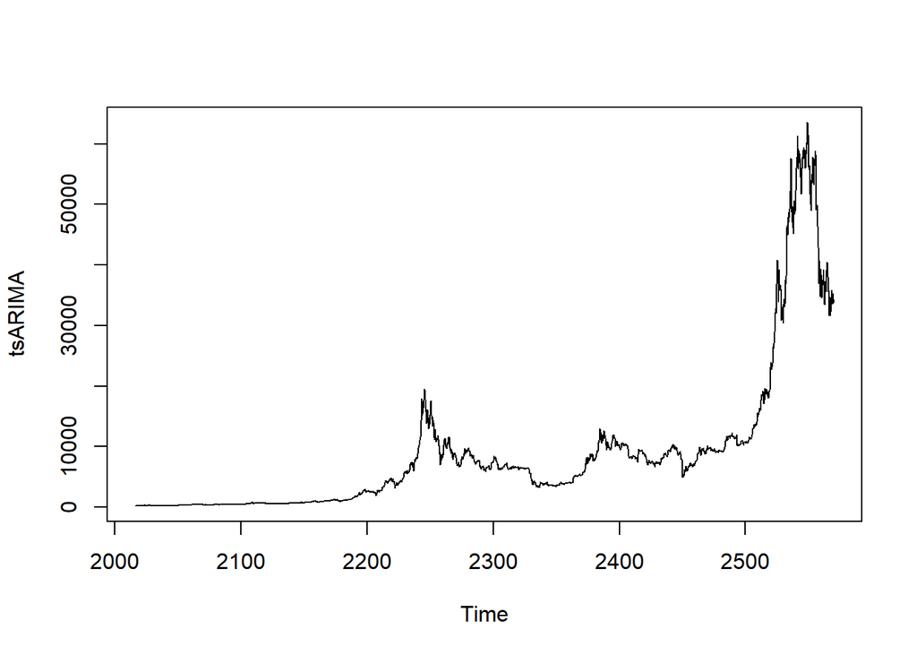

```r
## using ts() function for place in time-series format
tsARIMA = ts(ARIMA$y,frequency = 4,start = c(2015,6))
## ploting the time series formatted data
plot(tsARIMA)
```

```r
## using the auto.arima() function to get the optimal auto arima model
autoarima1 = auto.arima(tsARIMA)
autoarima1
```

```
## Series: tsARIMA
## ARIMA(2,1,2)(0,0,1)[4]
##
## Coefficients:
##           ar1      ar2     ma1     ma2    sma1
##       -0.4854  -0.9452  0.4289  0.9778  0.0756
## s.e.   0.0121   0.0095  0.0070  0.0086  0.0225
##
## sigma^2 estimated as 445108:  log likelihood=-17545.42
## AIC=35102.83   AICc=35102.87   BIC=35137.05
```

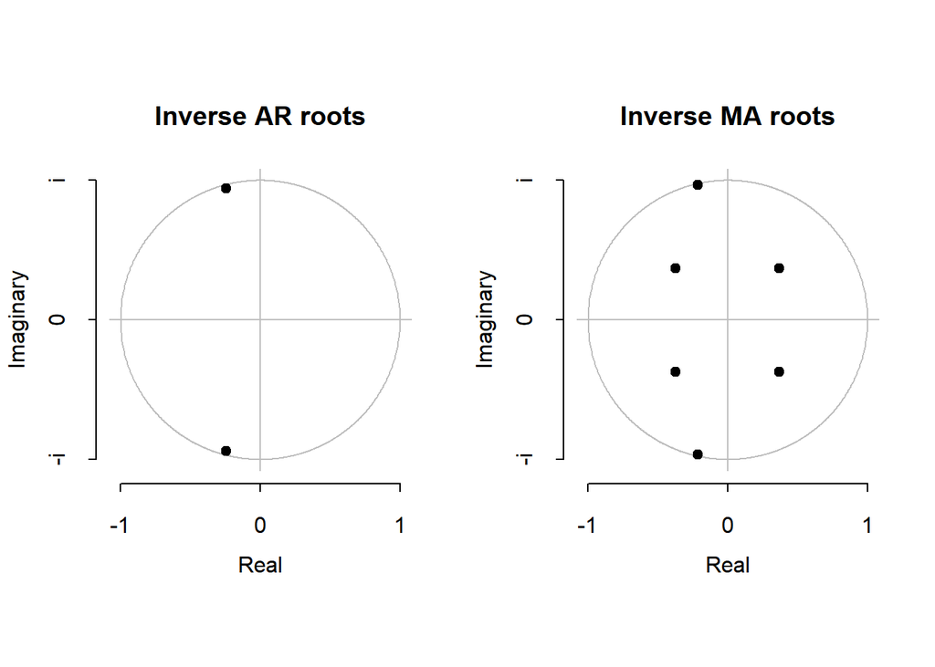

```r
plot(autoarima1)
```